# Three Patching Signatures of Branch Events under Token-Certified Prompt Edits

**Status:** rev 4 submission-cleanup, 2026-05-12. Target: NeurIPS interpretability workshop, 6-8 pages. Rev 4 applies the third expert review: prompt-LCP definition tightened, aligned-prompt controls labeled sampled explicitly, §3.2 reframed as “reserved-wave rule transfer”, rule-of-three iid caveat added, abstract/conclusion softened, held-out summary merged into §3.2, reverse-direction moved to §4 exploratory with branch prediction and forced-prefix replay, §3 trimmed to six subsections, denominator-flow table added at §3.1, all three wrong-donor matches tabulated in §3.5.

## Abstract

Tiny formatting edits can change a greedy LLM’s continuation. A space, newline, or bracket change is enough to branch the model onto a different first word, and sometimes a different answer. The patch that undoes the branch is not always at the edited token.

We study 82 token-certified prompt pairs across eight open models (Qwen 3.5 at 0.8B to 9B, Gemma 4 at E2B and E4B, base and instruct). For each pair we ask a concrete question: which residual-stream positions, if patched from the unedited run into the edited run, make the edited model pick the original next token? We find three recurring patching signatures. **Boundary rescue** (41/82): patching the first differing prompt token (the “prompt-LCP” position) is enough. **Generated-prefix rescue after silent divergence** (27/82): the top-1 pick does not change until several tokens in, and some position in the shared generated prefix is enough to restore the original token. **Tokenization-shift immediate rescue** (14/82): the edit sits at token 0 of the prompt, and the last prompt position rescues. No case in the panel needs a late handle alone: every case has at least one prompt-side position that works too, so strict late-only rescue is 0/82 (upper 95% bound ≈ 3.7% by the rule of three).

A decision rule fixed on the hand-curated waves transferred to a randomized held-out wave with no changes: on silent cases in the held-out wave, 29/30 had full generated-prefix rescue, against 21/22 on the curated waves. A donor-specificity control on qwen35_2b (three random donors per case, same position and layer) matched the target branch token in 10/10 self-patches and only 3/30 wrong-donor patches, arguing against a purely generic-perturbation explanation at least for this one-model control. We release **Branch Cards**, a JSON + HTML audit format for per-case evidence, with two example cards.

## 1. Introduction

Greedy decoding is deterministic. Fix the model, the prompt, the runtime, and the seed, and you get the same tokens out. But prompts that look equivalent to a person — the same sentence with or without an extra blank line, for example — are not equivalent to the tokenizer. Under greedy decoding, these small formatting edits reliably push the generation onto a different token, and it stays different from there.

This paper asks a concrete question: **when a tiny prompt edit makes the model pick a different next token at position t*, where in the forward pass can we patch the unedited model’s activation into the edited model and recover the original token?**

For each pair we patch four kinds of positions, one at a time:

- **prompt-LCP** (for “longest common prefix”): the first prompt token at which A and A′ differ. If both prompts share the first *k* tokens, this is the token at index *k*.
- **aligned-prompt controls**: sampled non-boundary positions from the shared prompt region (positions inside the common prefix, not the prompt-LCP position itself). Controls are a sample, not an exhaustive sweep.
- **generated-prefix**: any generated token that both runs produced the same before the branch.
- **final-context**: the last position before the model picks the branch token.

We say a position *rescues* the branch if, after substituting the unedited run’s residual activation at that position (best layer over all transformer blocks), the edited model’s top-1 pick matches the original branch token. We also report a metric-level variant (`rescue_fraction ≥ 1.0` on the A-minus-B logit contrast). The two agree in most cases; we flag the handful where they don’t.

The 82 cases cluster into three signatures under a deterministic rule:

1. **Boundary rescue** (41/82): the prompt-LCP position rescues.
2. **Generated-prefix rescue after silent divergence** (27/82): the visible branch comes several tokens after a silent logit shift; the prompt-LCP position is partial (median rescue fraction 0.54) and some generated-prefix position rescues fully.
3. **Tokenization-shift immediate rescue** (14/82): the edit sits at token 0 of the prompt; the last-prompt-position rescues (the prompt is short enough that this equals final-context at branch_t=0); prompt-LCP is partial (median 0.62).

No case in the panel has the opposite shape — no prompt-side position works but some late position does. The closest analog — “strict late-only” — is 0/82. With the rule of three, that puts the upper 95% bound on this pattern’s rate in the panel’s distribution at about 3.7%. This is an empirical result on our panel, not a theorem. Different edit families or larger panels might surface cases.

We treat this clustering as **operational** rather than mechanistic. We are classifying *where in the forward pass a branch can be undone*, not recovering a circuit. A different patch grid, model set, or edit family would likely surface different signatures. The signatures are useful descriptions, not discovered mechanisms.

**Contributions.**

- Three recurring patching signatures on 82 token-certified cases across eight open models, with a deterministic decision rule.
- A discovery-to-replication split: the rule fixed on the curated waves predicts the held-out wave’s signature distribution (silent full-rescue rate: discovery 21/22, held-out 29/30, combined 50/52).
- Negative controls. **0/82** cases are strict late-only (§3.3). A donor-specificity test on qwen35_2b shows strict replay 3/30 with wrong donors against 10/10 with self-patches (§3.5).
- **Branch Cards**: a JSON schema and HTML renderer packaging two runs, their divergence, and the patch evidence. Two example cards ship with the paper.

**What we do not claim.** We do not claim a mechanism, or that the three signatures correspond to distinct circuits. We do not claim boundary rescue is the canonical handle; it is 41 of 82. We do not claim strict late-only rescue is impossible, only that it is absent in this panel under this patch grid. Backend and precision settings shift branch timing by several tokens (up to 8.8 mean absolute tokens on Qwen 3.5-4B across SageMaker instance types), so our numbers are on matched backends.

## 2. Method

**Prompt pairs.** Each pair differs by a small, reviewer-visible tokenization edit: an inserted blank line, doubled internal space, added parentheses, tab after space, and so on. The apparent meaning is unchanged; only the tokenized form differs. We keep pairs with small token edit distance (typically 1 to 3) on the full formatted prompt, chat template and system prompt included.

**Decoding.** Greedy, no sampling, 256 max new tokens, bfloat16 on CUDA. Model revisions pinned in `configs/models.json`.

**Branch event.** We decode A and A′ and find `t*`, the first position where the two runs pick different token IDs. We flag a *silent divergence* event when the logit distributions diverge meaningfully (branch-JS ≥ 0.01 or top-1 margin ≤ 0.125) before the visible pick changes.

**Activation patching.** For each (position, layer) we substitute the A run’s residual activation into A′’s forward pass at that position and measure two things at the branch position:

- **Metric rescue.** `rescue_fraction = (patched − corrupt) / (clean − corrupt)` on the A-minus-B logit contrast. Full rescue means `rescue_fraction ≥ 1.0`.
- **Strict replay.** The patched top-1 at the branch position matches A’s branch token ID exactly.

Strict replay is the cleaner criterion for reviewers. Metric rescue is what the patching literature reports and what our panel CSVs record; we report both, and where they disagree we note it (§3.4).

We patch every layer. “A position class rescues” means some layer in that class produces full rescue or strict replay. We are testing that a sufficient handle exists somewhere in the class, not localizing a specific layer.

**Decision rule for signatures.** Applied to each case:

```
if the prompt-LCP position has metric rescue >= 1.0 at some layer:
    → boundary_rescue
elif first_diff_token == 0:
    → tokenization_shift_immediate_rescue
else:
    → generated_prefix_rescue_after_silent_divergence
```

The rule was specified on the curated waves (V1 through V3, 42 cases). It transferred to the held-out wave (V5, 40 cases) with no modification.

**Panels.**

- **Discovery**: 42 hand-curated cases across 8 models and 7 edit kinds.
- **Held-out**: 40 randomized cases drawn from the same token-certified pair set, independent of discovery.
- **Reverse**: 21 discovery cases re-run with A and A′ swapped.

All runs went through SageMaker against pinned model revisions. The statistical unit is the prompt pair.

## 3. Results

### 3.1 Three patching signatures

The decision rule assigns every case in the 82-case panel to one signature:

| Signature | Count | Defining handle |
| --- | --- | --- |
| boundary_rescue | 41 | prompt-LCP full rescue |
| generated_prefix_rescue_after_silent_divergence | 27 | some generated-prefix position fully rescues |
| tokenization_shift_immediate_rescue | 14 | edit at token 0; last-prompt-position rescues |

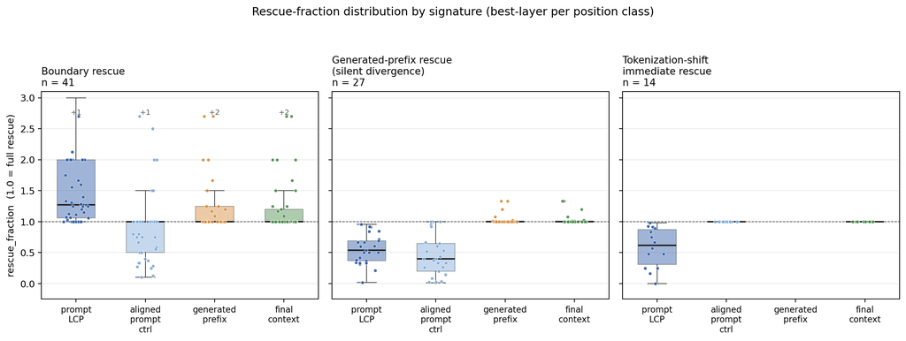

**Figure 1** (`figures/signature_rescue_panel.pdf`). Box + jittered strip of best-layer rescue_fraction per case at the four position classes, one panel per signature. Each signature’s characteristic shape reads at a glance: boundary has prompt-LCP well above 1.0 (and other classes also rescuing); generated-prefix-after-silent has prompt-LCP and aligned-prompt controls clearly below 1.0 with generated-prefix and final-context glued to 1.0; tokenization-shift- immediate has prompt-LCP below 1.0 with aligned-prompt / final- context at 1.0 and generated-prefix empty (immediate branches have no shared generated prefix). Source: `runs/rankings/activation_patch_comparison/case_level_summary.csv`.

**Denominator reference.** Several headline numbers use different denominators; we list them together here to keep the paper’s counts legible.

| Quantity | Number | Denominator |
| --- | --- | --- |
| primary panel | 82 | — |
| silent-divergence cases | 52 | of 82 |
| silent cases with full gen-prefix rescue | 50 | of 52 silent |
| generated-prefix signature (prompt-LCP partial) | 27 | of 82 |
| boundary signature | 41 | of 82 |
| tokenization-shift-immediate signature | 14 | of 82 |
| strict assayed late-only | 0 | of 82 |
| held-out (V5) cases | 40 | of 82 |
| reverse-direction matched cases | 21 | subset of discovery |
| donor-specificity control (qwen35_2b) | 10 cases × 3 donors | 30 trials |

### 3.2 Reserved-wave rule transfer

We chose the signature decision rule by looking at the curated waves. The held-out wave (V5) had been run through SageMaker before we wrote the rule down, so the patch CSVs for both waves existed when we formalized the signatures. What V5 did *not* see was the rule, the signature labels, or any hand-selection — V5 cases are a randomized sample from the token-certified pair set.

So this is a rule-transfer check on a reserved wave, not a preregistered prediction. The question it answers is: does the rule we chose on the curated cases describe the randomized held-out cases without adjustment?

One signature has a concrete numeric test: in silent-divergence cases, some generated-prefix position should fully rescue.

- **Curated (discovery).** 22 silent cases; 21 with full generated- prefix rescue.
- **Held-out.** 30 silent cases; 29 with full generated-prefix rescue.
- **Combined.** 50 of 52 silent cases.

**Held-out summary.** Across all 40 V5 cases, 39/40 had metric full rescue at some position and 36/40 had strict replay. The signature distribution matches discovery within resampling noise.

The caveat on the 50/52 number: the generated-prefix position class includes several positions within a case. “Some generated-prefix position rescues” is a weaker claim than “a specific generated-prefix position rescues.” We report the rate at which *any* such position rescues; we do not claim the same index across cases.

### 3.3 Strict assayed late-only rescue: 0 of 82

We defined this case as: no prompt-side position rescues (neither prompt-LCP nor any aligned-prompt control has full rescue at any layer), and some late position does. Zero cases in our panel fit. Applying the rule-of-three heuristic to 0/82 gives an upper 95% bound of about 3.7%, under the assumption that cases are independent draws from the panel’s distribution. Our pairs are not iid — multiple pairs per edit kind and per model share structure — so the bound is heuristic, not a formal confidence interval.

“Assayed” is load-bearing. Aligned-prompt controls are sampled, not exhaustive. We rule out strict late-only *among tested* prompt positions, not among all possible ones.

### 3.4 Metric rescue and strict replay agree in most cases

For 76 of 82 cases, the position-class with full metric rescue (rescue_fraction ≥ 1.0) also produces strict replay (patched top-1 = A’s branch token ID). The six disagreements all have a near-match top-1: a surface variant of A’s branch token, usually differing in a leading space or in capitalization. We list them in the supplementary table and report both metrics throughout.

### 3.5 Donor-specificity check

The signatures could be cheap: maybe *any* activation at the signature position, patched in, pushes the edited model across the threshold, not specifically the unedited run’s activation. To test this we ran a small local check on qwen35_2b.

For each of 10 cases whose best signature position rescued under strict replay, we fixed the target case’s recipient, position, and winning layer, and patched from three random donor cases (same model, different target A-branch token). Self-patch (the unedited run’s own activation) rescued 10 of 10 cases strictly. Wrong-donor patches rescued 3 of 30. Median rescue_fraction: 1.00 for self-patch, 0.00 for wrong-donor.

Three donor strict-matches is not zero, so we list all three:

| Target case | Sig | Pos / layer | Target A-token | Donor A-token |
| --- | --- | --- | --- | --- |
| blank_line_wrap_0521 | boundary | prompt_lcp / L3 | `Retry` | `ensure` |
| parenthesize_word_0344 | boundary | prompt_lcp / L0 | `Quality` | `established` |
| line_wrap_0378 | boundary | prompt_lcp / L1 | `Retry` | `ensure` |

All three are boundary-rescue cases patched at the prompt-LCP position, and in each the target’s A-token (`Retry`, `Quality`) is a common continuation word that the recipient context already favors. Two of the three use the same donor case. The pattern is consistent with prompt-LCP positions being sensitive to a range of donor activations when the target branch token itself is a predictable completion, rather than with the signature failing. Strict replay still fails in 27 of 30 wrong-donor trials.

We ran this check on only one model. Treat it as a rule-out: if the signatures had been trivially satisfiable by any donor, strict replay would have been much higher than 3/30.

### 3.6 Failures and edge cases

- Two silent cases (of 52) do not reach full generated-prefix rescue. Both have at most one shared generated token before the branch, and the best handle is the final-context position.
- Two held-out cases have metric rescue ≥ 1.0 but fail strict replay by whitespace or capitalization only.
- One panel case has a corrupt baseline whose A-minus-B metric is nearly equal to the clean baseline, so the metric rescue fraction is undefined. We exclude it from metric rescue statistics but include it in strict replay.

## 4. Additional checks

Three exploratory signals line up with the patching story. None is used to define or validate signatures; we include them because they point the same direction from different angles.

**Reverse-direction patching.** Twenty-one discovery cases ran with A and A′ swapped. In at least one direction, all 21 had metric full rescue. In both directions, 19 had strict replay. The best-position class agreed between directions in 16. Supportive rather than decisive; 16 of 21 is a middling agreement rate.

**Branch prediction from trajectory signals.** Across 52 silent cases, two features — low top-1 margin and high JS divergence with the other run — detect the branch at or just before it commits (at-branch AUROC 0.947 and 0.883 respectively). Strict pre-branch (one token before the visible pick) AUROC drops into the 0.6–0.7 range. Branches are detectable close in time; this says nothing about mechanism.

**Forced-prefix replay.** A black-box analog on 11 qwen35_2b cases: force A′ through A’s pre-branch tokens and A’s branch token, free-decode 10 more tokens, measure token LCP with A’s continuation. Mean rejoin by signature: 8.0 for boundary (n=8), 5.0 for gen-prefix silent (n=2, split between 10 and 0), 10 for tok-shift (n=1). With n = 11 this is a continuity check, not a result. The metric under-counts cases where the forced continuation stays on A’s topic but picks different surface tokens.

## 5. Discussion

**A continuum of sufficient handles.** The signatures differ in which position rescues, not in whether one does. When the edit perturbs the prompt locally, the prompt-LCP position is enough. When the edit’s effect has already nudged the logits before the visible top-1 changes, some position in the generated prefix is enough. When the edit sits at token 0, last-prompt-position (the only non-boundary prompt position available with so short a prompt) is enough. We aren’t saying the branch “migrates” or “accumulates.” We’re saying a sufficient handle sits at those positions.

**What the signatures are not.** We do not observe a clean basin-switch / cliff-slip split: margin distributions across signatures overlap. We do not claim these patching signatures are distinct circuits. A reviewer could read the signatures as definitions induced by our patch grid and best-layer search; the donor-specificity check (§3.5) is our response, not a final answer.

**Reproducibility hazards.**

- *Backend and precision change branch timing.* Across SageMaker instance types, mean absolute branch-time drift is 4.25 tokens on Qwen 3.5-2B and 8.80 on Qwen 3.5-4B. Local MPS float16 and SageMaker bfloat16 are not interchangeable for branch-timing claims.
- *Reasoning scaffolds change the statistics.* Models whose chat templates produce visible reasoning scaffolds show different branch patterns. Our panel mixes scaffolded and non-scaffolded models.

## 6. Limitations

- **Panel size.** 82 cases across 8 models. Held-out 40 cases reduce selection-bias concern but do not establish universality.
- **Strict late-only is empirical, not formal.** Upper 95% bound on the rate in this panel’s distribution is about 3.7% (rule of three). Other edit families or larger panels might surface cases.
- **Aligned-prompt controls are sampled.** The “no prompt-side position rescues” half of strict late-only rules out the pattern *among the positions we test*, not among all possible prompt positions.
- **Best-layer search is an existence claim.** We test whether some layer in a position class rescues, not where precisely.
- **Tokenization-shift-immediate has structural confounds.** All 14 cases have `first_diff_token = 0`. The signature may be partly a definitional artifact of the LCP convention at token 0. We report it distinctly rather than fold it into boundary rescue.
- **Donor-specificity check is one model.** The qwen35_2b check in §3.5 does not prove donor-specificity for every panel model.
- **Backend and precision caveats** as above.
- **Prompt pair is the unit.** Multiple pairs per edit kind and model share structure we do not model.
- **Auxiliary checks are low-N.** §4 is supportive, not standalone.

## 7. Related Work

**Activation patching and causal tracing.** Our patching metric and aligned-position setup follow the causal-tracing lineage. Vig et al. (2020) introduced causal mediation analysis for interpreting language-model components; Meng et al. (2022) extended the technique to factual association recall with ROME; Geiger et al. (2021) give the formal causal-abstraction framing that underpins interchange interventions. Heimersheim & Nanda (2024) document practical interpretation pitfalls, and Zhang & Nanda (2024) compare metrics and corruption strategies across common activation-patching setups. We adopt the “existence of a sufficient handle at some layer” framing these write-ups recommend and apply position-class-aligned patching to classify where a branch can be rescued, not to localize a circuit.

**Prompt sensitivity.** Sclar et al. (2024) document large accuracy swings under meaning-preserving format edits in few-shot settings. Cao et al. (2024) propose RobustAlpacaEval and show worst-prompt performance is substantially below average. PromptEval (Polo et al., 2024) estimates performance distributions across many prompt templates efficiently; POSIX (Chatterjee et al., 2024) introduces a prompt-sensitivity index; Errica et al. (2025, NAACL) quantifies sensitivity and consistency under prompt rephrasing; Pecher et al. (2026) argue much of this variance reflects prompt underspecification. These works correlate prompt choice with accuracy. Ours intervenes at the residual-stream level on tokenizer-certified pairs to ask where the branch commits causally, which is a different question.

**Black-box conditioned rollouts.** Bogdan et al. (2025, “Thought Anchors”) introduce a black-box counterfactual-resampling method for localizing which reasoning steps matter most in a chain of thought. Our forced-prefix check in §4 is in the same family — fix a shared prefix, let the model continue, measure whether it sticks to the original trajectory — but applied to formatting-driven branches rather than reasoning-step importance.

## 8. Ethics, licenses, and data release

**Models.** We use the Qwen 3.5 family (Alibaba, Apache 2.0) at 0.8B, 2B, 4B, and 9B, and the Gemma 4 family (Google, Gemma Terms of Use) at E2B and E4B, both base and instruct. No model weights are redistributed; we record pinned Hugging Face model revisions in each Branch Card’s `run_a.runtime.model_revision` field. Users replaying our results agree to the respective model licenses when they pull the weights.

**Intended use.** This paper is interpretability research. The token-certified edit methodology could in principle be used to search for low-effort prompt perturbations that elicit specific outputs, including harmful ones. Our focus is understanding where branches commit; we do not release, benchmark, or optimize jailbreak prompts, and the 82-case panel is restricted to neutral instruction-following tasks (definitions, summaries, how-to explanations).

**Data.** All prompt pairs were generated for this project. No user data, no scraped web content. Prompt-pair seed templates are in `configs/prompt_pairs_token_certified/` and the full pair JSON files are released with the code.

**Compute.** Patching runs used roughly 60 SageMaker GPU hours total (ml.g6e.2xlarge and ml.g5.2xlarge mixed). Donor and forced-prefix replay checks ran in under ten minutes on a 64GB MacBook (MPS float16). No model training or fine-tuning was required.

## Appendix A — Branch Cards

A Branch Card is a JSON document (`branchcard/0.1`, Pydantic- validated) that pairs two runs with their divergence and patch evidence. Top-level fields:

- `run_a`, `run_b` — prompt, token IDs, generation, runtime metadata (torch, dtype, device, seed, chat template, system prompt).
- `edit` — token edit distance, prompt-LCP position, visible diff span.
- `branch` — `branch_t`, event kind, top-k on both sides.
- `replay` — deterministic reproducibility, forced-prefix results.
- `patch_evidence` — signature, best position class, best layer, rescue fractions per class.
- `suspected_controlling_span` — heuristic; marked `derived`.
- `selection_provenance` — wave, pool, archetype.
- `artifacts` — path + SHA-256 for every upstream CSV/JSONL.

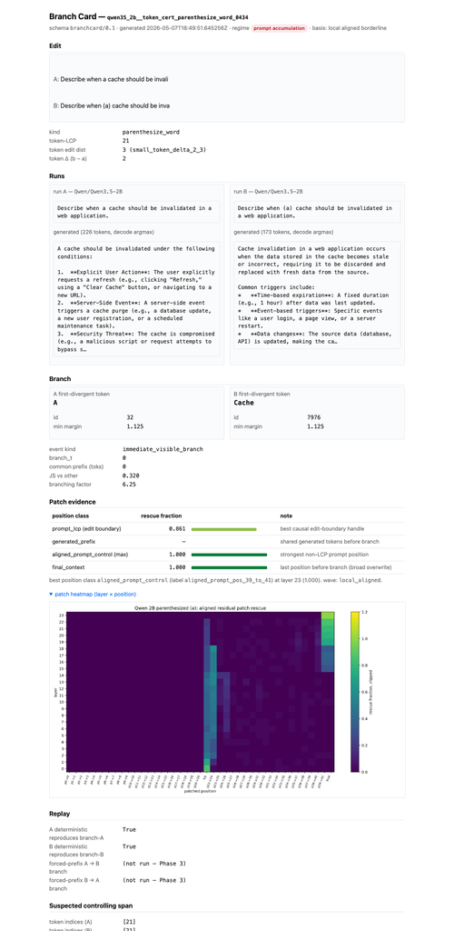

This is an audit format for reproducing per-case evidence, not a general branch-debugging tool.

## References

- Vig, J., Gehrmann, S., Belinkov, Y., Qian, S., Nevo, D., Singer, Y., & Shieber, S. (2020). *Causal Mediation Analysis for Interpreting Neural NLP: The Case of Gender Bias.* NeurIPS 2020. arXiv:2004.12265.
- Meng, K., Bau, D., Andonian, A., & Belinkov, Y. (2022). *Locating and Editing Factual Associations in GPT.* NeurIPS 2022. arXiv:2202.05262.
- Geiger, A., Lu, H., Icard, T., & Potts, C. (2021). *Causal Abstractions of Neural Networks.* NeurIPS 2021. arXiv:2106.02997.
- Heimersheim, S., & Nanda, N. (2024). *How to use and interpret activation patching.* arXiv:2404.15255.
- Zhang, F., & Nanda, N. (2024). *Towards Best Practices of Activation Patching in Language Models: Metrics and Methods.* arXiv:2309.16042.
- Sclar, M., Choi, Y., Tsvetkov, Y., & Suhr, A. (2024). *Quantifying Language Models’ Sensitivity to Spurious Features in Prompt Design.* ICLR 2024. arXiv:2310.11324.
- Cao, B., Yan, Y., Luo, T., Wang, M., Chen, W., & Zhang, M. (2024). *On the Worst Prompt Performance of Large Language Models.* NeurIPS 2024. arXiv:2406.10248.
- Polo, F. M., Xu, R., Weber, L., Silva, M., Bhardwaj, O., Choshen, L., de Oliveira, A. F. M., Sun, Y., & Yurochkin, M. (2024). *Efficient multi-prompt evaluation of LLMs (PromptEval).* NeurIPS 2024. arXiv:2405.17202.
- Chatterjee, A., Renduchintala, H. S. V. N. S. K., Bhatia, S., & Chakraborty, T. (2024). *POSIX: A Prompt Sensitivity Index For Large Language Models.* arXiv:2410.02185.
- Errica, F., Siracusano, G., Sanvito, D., & Bifulco, R. (2025). *What Did I Do Wrong? Quantifying LLMs’ Sensitivity and Consistency to Prompt Engineering.* NAACL 2025. arXiv:2406.12334.
- Pecher, B., Srba, I., Bielikova, M., & Vanschoren, J. (2026). *Revisiting Prompt Sensitivity in Large Language Models for Text Classification: The Role of Prompt Underspecification.* arXiv:2602.04297.
- Bogdan, P. C., Macar, U., Nanda, N., & Conmy, A. (2025). *Thought Anchors: Which LLM Reasoning Steps Matter?* arXiv:2506.19143.